# CMJ Visualization Markdown

2024-11-19

## Familiarization and Cleaning

1. Load appropriate packages and libraries
2. Import CMJ data
3. Familiarize myself data structure, formatting, ranges, etc in Excel through exploratory sorting/filtering
4. Remove outliers based on weight (-1), team (NA), and metrics of +/- 3 standard deviations

## Data Analysis

1. Correlation analysis to evaluate similarity when selecting CMJ metrics, trying to avoid redundancy

```
# Reorganize data long to wide for correlation analysis
cmj_wide <- cmj_data_clean %>%
  group_by(player_id, test_date, metric) %>%
  summarize(mean_value = mean(value), .groups = 'drop') %>%
  pivot_wider(
    id_cols = c(player_id, test_date),
    names_from = metric,
    values_from = mean_value
  )

# Calculate correlations for metrics
cor_matrix <- round(cor(cmj_wide[,3:ncol(cmj_wide)], use = "complete.obs"), 2)
```

2. Define selected CMJ metrics to be used for analysis

```
# Define the selected metrics
selected_metrics <- c("Concentric Mean Power / BM", "Eccentric Mean Power / BM",
                      "Force at Zero Velocity", "RSI-modified", "Vertical Velocity at Takeoff")
```

```
# Calculate percentiles for Player 3185 vs Team
Team_comparison <- cmj_data_clean %>%
  filter(parent_team_name == "Team" | player_id == "3185") %>%
  group_by(metric) %>%
  filter(metric %in% selected_metrics) %>%
  summarize(
    player_value = mean(value[player_id == "3185"]),
    team_percentile = ecdf(value[parent_team_name == "Team"])(mean(value[player_id == "3185"])) * 100
  ) %>%
  ungroup()

# Calculate percentiles for Player 3185 vs Position 3 (excluding Team)
position_comparison <- cmj_data_clean %>%
  filter((primary_position == "3" & parent_team_name != "Team") | player_id == "3185") %>%
  group_by(metric) %>%
  filter(metric %in% selected_metrics) %>%
  summarize(
    player_value = mean(value[player_id == "3185"]),
    position_percentile = ecdf(value[primary_position == "3" & parent_team_name != "Team"])(mean(value[player_id == "3185"])) * 100
  ) %>%
  ungroup()}
```

## Plot Creation

1. Correlation plot creation

```
# Create correlation plot
png("correlation_plot.png", width = 1500, height = 1300, res = 150)

# Reformat plot for easier readability
corrplot(cor_matrix, method = "color", type = "upper", order = "alphabet", tl.col = "black",
         tl.srt = 45, addCoef.col = "black", number.cex = 0.9, tl.cex = 0.9, mar = c(0,0,2,0))
dev.off()
```

2. Formatting data for each plot creation

```
# For Team comparison
team_spider_data <- data.frame(
  matrix(c(100, 100, 100, 100, 100,
           0, 0, 0, 0, 0,
           50, 50, 50, 50, 50,
           team_comparison$team_percentile),
         nrow = 4, byrow = TRUE)
)
colnames(team_spider_data) <- selected_metrics
rownames(team_spider_data) <- c("max", "min", "team_avg", "player")

# For Position 3 comparison
position_spider_data <- data.frame(
  matrix(c(100, 100, 100, 100, 100,
           0, 0, 0, 0, 0,
           50, 50, 50, 50, 50,
           position_comparison$position_percentile),
         nrow = 4, byrow = TRUE)
)
colnames(position_spider_data) <- selected_metrics
rownames(position_spider_data) <- c("max", "min", "position_avg", "player")
```

3. Creating each plot

```
# vs Team
png("player_vs_team_spider.png", width = 1000, height = 900, res = 100)
layout(matrix(c(1,2), nrow=2, ncol=1), heights=c(4,1))

# Spider plot
par(mar=c(3, 4, 2, 4))
radarchart(team_spider_data,
           pcol = c("blue", "red"),
           pfcol = c(rgb(0, 0, 1, 0.2),
                     rgb(1, 0, 0, 0.2)),
           plwd = 2,
           cglcol = "grey",
           cglty = 1,
           axislabcol = "grey",
           caxislabels = seq(0, 100, 25),
           title = "Player 3185 vs Team (Percentiles)")
legend("topright",
       legend = c("Team Average", "Player 3185"),
       col = c("blue", "red"),
       lwd = 2,
       pch = 20,
       pt.cex = 2,
       bty = "n")

# Percentiles text
par(mar=c(0,0,0,0))
plot.new()
text(0.5, 0.9, "Player 3185 Percentiles:", font=2)
for(i in 1:length(selected_metrics)) {
  text(0.5, 0.8-i*0.15,
       paste(selected_metrics[i], ": ",
             round(team_comparison$team_percentile[i], 1), "%"))
}
dev.off()

# vs Position 3
png("player_vs_position3_spider.png", width = 1000, height = 900, res = 100)
layout(matrix(c(1,2), nrow=2, ncol=1), heights=c(4,1))

# Spider plot
```

[output cut: 14 more lines]

```
       lwd = 2,
       pch = 20,
       pt.cex = 2,
       bty = "n")

# Percentiles text
par(mar=c(0,0,0,0))
plot.new()
text(0.5, 0.9, "Player 3185 Percentiles:", font=2)
for(i in 1:length(selected_metrics)) {
  text(0.5, 0.8-i*0.15,
       paste(selected_metrics[i], ": ",
             round(position_comparison$position_percentile[i], 1), "%"))
}
dev.off()
```

## Visualizations

1. Correlation Matrix of CMJ Metrics

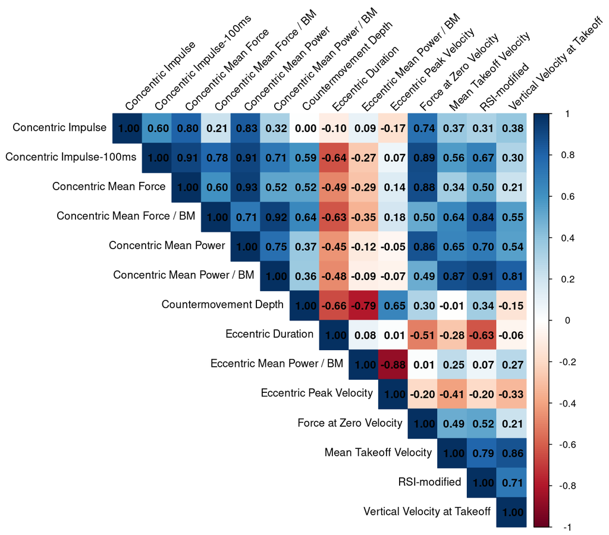

   Correlation Matrix of CMJ Metrics

2. Player 3185 Percentiles vs Team

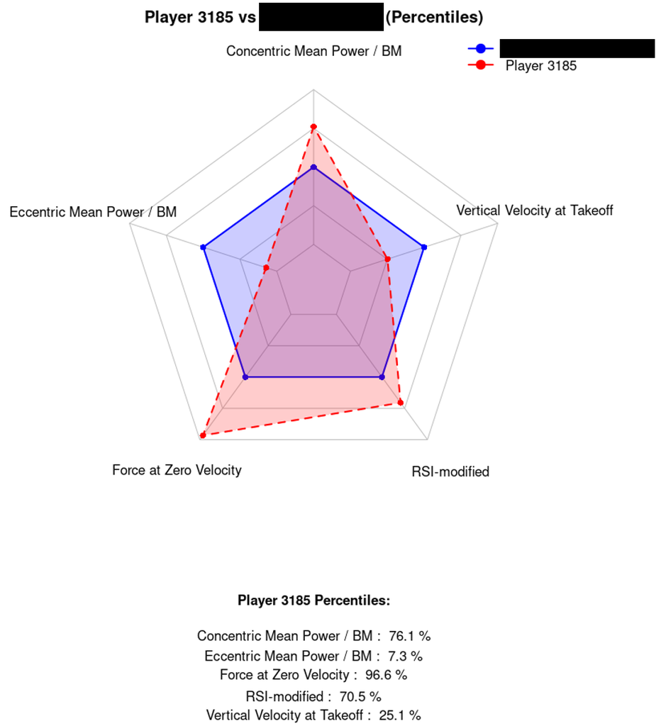

   Player 3185 Percentiles vs Team

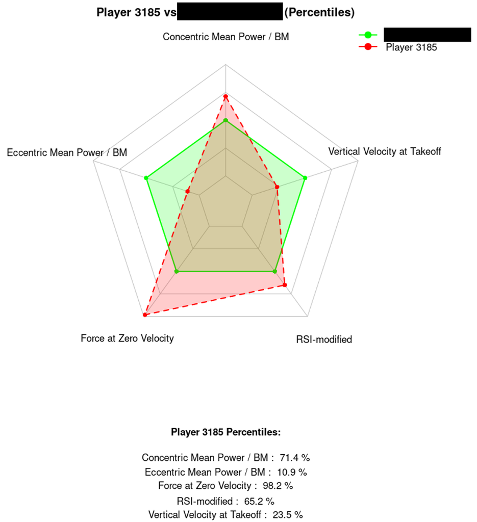

## Key Considerations

– **Selected force plate metrics:**

- *Vertical Velocity at Takeoff*: proxy for jump height, simple performance metric
- *RSI-modified*: ratio of jump effectiveness, output vs input (Time to Takeoff)
- *Force at Zero Velocity*: strength number, highest force created during jump
- *Concentric Mean Power / BM*: relative to BM for inter-athlete comparison, concentric number to compare to eccentric
- *Eccentric Mean Power / BM*: relative to BM for inter-athlete comparison, eccentric number to compare to concentric

– **Logic and Thought Process**

- With Excel’s ease of use for data viewing and sorting, I looked at the minimums and maximums of each column, finding -1 for some Weight entries and NA for Team entries
- As all CMJ metrics are “bounded” with relative physiological minimum and maximum thresholds, but with plenty of inter-athletes variation, I chose 3 standard deviations for outlier detection and removal as opposed to a slightly more stringent method like IQR
- A percentile would be an easier ranking number (as opposed to a Z-score, for example) for an athlete to understand

– **Findings and Practical Applications**

- My synopsis:
  - Player 3185 (randomly selected) is very strong in the +96th percentile for *Force at Zero Velocity*
    - I’m assuming Player 3185 is bouncy and forceful in shallow joints angles. A below average *Vertical Velocity at Takeoff* plus an above average *RSI-modified* means Time to Takeoff must be very quick
      - This is supported with above average *Concentric Mean Power / BM* and below average *Eccentric Mean Power / BM*
  - Player 3185 could benefit from some complementary full-range of motion strength training and deeper joint angle plyometrics

– **Limitations and Future Considerations**

- Force at Zero Velocity had the most outliers removed, I would look more into that metric’s reliability and see if there’s potentially a more consistent metric for strength
- Dive into intra- and inter-athlete reliability per metric
- Evaluate athlete’s spider graph in the first vs last month of training, see if any significant improvements have been made
- Find correlations of Team to League Average to potentially avoid redundancy. However, since the Team is obviously the best in the league at drafting and developing, I attempted to give the athlete some reassurance by also including league averages